# Længder og vinkler

# Introduktion

Vinkler, afstande og arealer er helt centrale for landinspektører. Målforholdet er forholdet mellem længder i naturen og i kort og kan bestemmes, når kortet er givet som funktion af geografiske koordinater, $(\lambda,\varphi)$, længde og bredde.

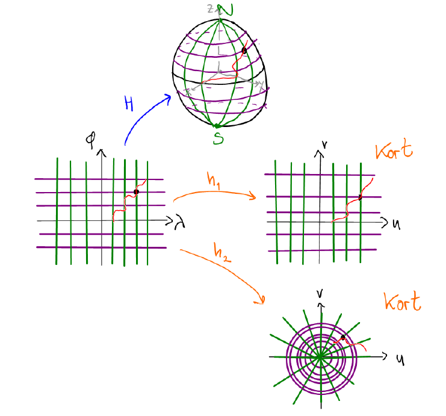

Figur 1: $H(\lambda,\varphi)$ er $(x,y,z)$-koordinater for et punkt med længde og bredde $(\lambda,\varphi)$. Afbildningerne $h_1$ og $h_2$ er to forskellige kort.

Målforholdet er ikke nødvendigvis konstant, men vil i det generelle tilfælde afhænge af, hvilket punkt man står i og hvilken retning man kigger. For eksempel er Mercatorprojektionen på Figur 2 (a) givet med $h(\lambda,\varphi)=\big(\lambda, \ln(\tan(\frac{\pi}{4}+\frac{\varphi}{2}))\big)$, og I skal senere i jeres studie se, at målforholdet er $1/\cos(\varphi)$. Altså afhænger målforholdet af breddegraden. Et andet eksempel er projektionen på Figur 2 (b), hvor $g(\lambda,\varphi) = \big(\lambda,\sin(\varphi)\big)$. Her afhænger målforholdet både af bredden og retningen, man kigger i. Man kan altså sige, at kortet “strækker forskelligt i forskellige retninger”.

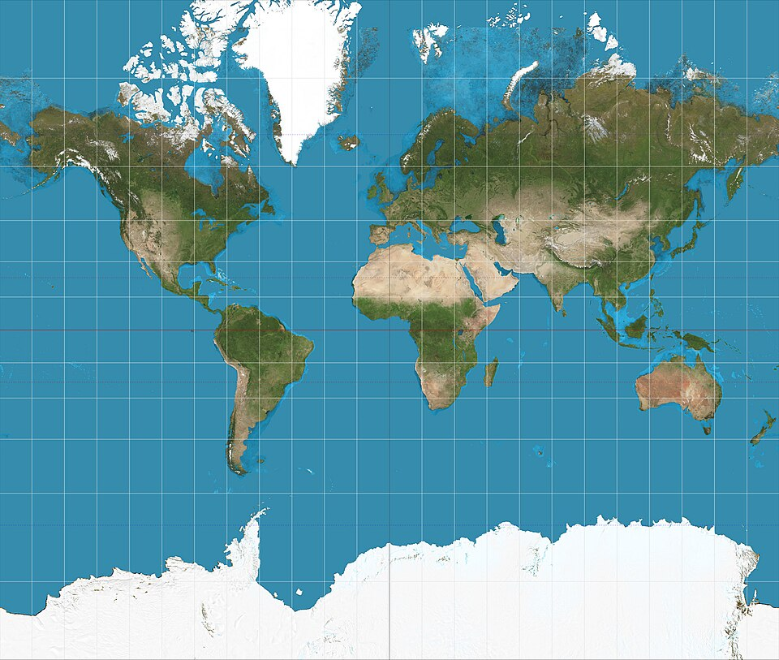

(a) [Mercatorprojektionen](https://commons.wikimedia.org/wiki/File:Mercator_projection_SW.jpg)

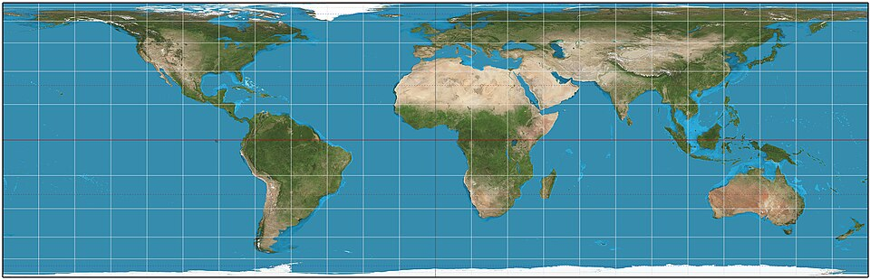

(b) [Archimedes-Lambert-projektionen](https://commons.wikimedia.org/wiki/File:Lambert_cylindrical_equal-area_projection_SW.jpg)

Figur 2: To forskellige cylinderprojektioner. Begge er lavet af Strebe og udgivet under [CC-BY-SA 3.0](https://creativecommons.org/licenses/by-sa/3.0/deed.en).

I denne workshop skal se på, hvad lineære afbildninger gør ved afstande og arealer. I får behov for følgende definitioner og formler for vektorer $\mathbf{x},\mathbf{y}\in\mathbb{R}^n$.

1. Skalarproduktet mellem $\mathbf{x}$ og $\mathbf{y}$ er $\mathbf{x}\cdot\mathbf{y}=\mathbf{x}^\top\mathbf{y}$, hvor højresiden er et matrixprodukt.
2. Længden af en vektor er $\lvert\mathbf{x}\rvert = \sqrt{\mathbf{x}\cdot\mathbf{x}}$.
3. Afstanden mellem $\mathbf{x}$ og $\mathbf{y}$ er $\lvert\mathbf{y}-\mathbf{x}\rvert$.
4. Hvis $\alpha$ er vinklen mellem $\mathbf{x}$ og $\mathbf{y}$, så gælder $\cos(\alpha)=\frac{\mathbf{x}\cdot\mathbf{y}}{\lvert\mathbf{x}\rvert\,\lvert\mathbf{y}\rvert}$.
5. Målforholdet for en lineær afbildning $\mathbf{x}\mapsto A\mathbf{x}$ i retningen af $\mathbf{x}$ er $m(A,\mathbf{x})= \frac{\lvert A\mathbf{x}\rvert}{\lvert\mathbf{x}\rvert}$.
6. I både planet og rummet vil parallelogrammet udspændt af $\mathbf{x}$ og $\mathbf{y}$ have areal $\sqrt{\lvert\mathbf{x}\rvert^2\lvert\mathbf{y}\rvert^2 - (\mathbf{x}\cdot\mathbf{y})^2}.$

# Delopgave 1

1. Hvis $A$ er en $m\times n$-matrix, så er
   $$A\mathbf{x}\cdot A\mathbf{y}= (A\mathbf{x})^\top A\mathbf{y} = \mathbf{x}^\top A^\top A\mathbf{y}= \mathbf{x}\cdot A^\top A\mathbf{y},$$
   hvor $\cdot$ betegner skalarprodukter, og de resterende produkter er matrixprodukter.

   Forklar hvert lighedstegn i denne udledning, og bestem størrelsen af $A^\top A$.

   Vis, at målforholdet for den lineære afbildning $\mathbf{x}\mapsto A\mathbf{x}$ i retning af en vektor $\mathbf{v}$ er givet ved
   $$m(A,\mathbf{v}) = \sqrt{\frac{\mathbf{v}A^\top A\mathbf{v}}{\mathbf{v}\cdot\mathbf{v}}}.$$
2. Vi betragter nu den lineære transformation $\mathbf{x}\mapsto B\mathbf{x}$, hvor
   $$B = \left[\begin{array}{rr}
   1 & -2\\
   3 & 2
   \end{array}
   \right].$$
   1. Udregn $B^\top B$.
   2. Lad $\mathbf{e}_1$ og $\mathbf{e}_2$ betegne standardbasisvektorerne i $\mathbf{R}^2$. Brug $B^\top B$ og resultaterne fra første spørgsmål til at beregne
      $$\lvert B\mathbf{e}_1\rvert\quad \lvert B\mathbf{e}_2\rvert\quad \lvert B(\mathbf{e}_1+\mathbf{e}_2)\rvert\quad\text{og}\quad B\mathbf{e}_1\cdot B\mathbf{e}_2.$$

      Hvad er målforholdet i retning $\mathbf{e}_1$ og $\mathbf{e}_2$?
   3. Vis, at målforholdet for en generel vektor $\mathbf{x}=[x_1\: x_2]^\top$ er
      $$m(B,\mathbf{x}) = \sqrt{\frac{10x_1^2 + 8x_1x_2 + 8x_2^2}{x_1^2 + x_2^2}}.$$
   4. Vis, at afstanden fra $B\mathbf{x}$ til $B\mathbf{y}$ er $\lvert B(\mathbf{y}-\mathbf{x})\rvert$, og at
      $$\lvert B\mathbf{y}-B\mathbf{x}\rvert = m(B,\mathbf{y}-\mathbf{x}) \lvert\mathbf{y}-\mathbf{x}\rvert,$$
      altså at afstanden fra $B\mathbf{x}$ til $B\mathbf{y}$ fås ved at multiplicere afstanden fra $\mathbf{x}$ til $\mathbf{y}$ med målforholdet i retningen $\mathbf{y}-\mathbf{x}$.
   5. Det viser sig, at arealer også er forbundet med $B^\top B$: For en $2\times 2$- eller $3\times 2$-matrix $A$ gælder, at arealet af parallelogrammet udspændt af $A\mathbf{x}$ og $A\mathbf{y}$ er givet ved
      $$\sqrt{\det(A^\top A)} \sqrt{\lvert\mathbf{x}\rvert^2 \lvert\mathbf{y}\rvert^2 - (\mathbf{x}\cdot\mathbf{y})^2}.$$
      Brug dette til at afgøre, om den lineære afbildning $\mathbf{x}\mapsto B\mathbf{x}$ er arealtro – altså om den bevarer arealer.
3. Lad $A$ være en $2\times 2$- eller $3\times 2$-matrix. Formuler en generel betingelse for, at afbildningen $\mathbf{x}\mapsto A\mathbf{x}$ er arealtro.

# Delopgave 2

Senere i kurset skal I se, at hvis en $n\times n$-matrix $X$ er symmetrisk – altså at $X^\top = X$ – så kan den altid diagonaliseres på formen $X=PDP^\top$, hvor bassisskiftmatricen $P$ opfylder $P^\top=P^{-1}$. Da vil søjlerne i $P$ udgøre en basis for $\mathbb{R}^n$, de vil være enhedsvektorer, de vil egenvektorer for $X$ og de vil være parvist vinkelrette.

1. Find matricer $P$ og $D$ som ovenfor, når $X=A^\top A$ for hver af de to matricer
   $$A=\left[
   \begin{array}{rr}
   1 & -1\\
   0 & 2\\
   2 & 0
   \end{array}
   \right]
   \quad\text{og}\quad
   \left[
   \begin{array}{rrr}
   1 & -1 & 0\\
   0 & 1 & 1\\
   \end{array}
   \right].$$

**Vink**

I skal bestemme egenværdier og egenvektorer for $A^\top A$.

For den sidste matrix har $A^\top A$ egenvektorer
$$\left[
\begin{array}{r}
1\\ 0\\ 1
\end{array}
\right],
\left[
\begin{array}{r}
-1\\ 2\\ 1
\end{array}
\right],
\left[
\begin{array}{r}
1\\ 1\\ -1
\end{array}
\right].$$

1. Vis, at $A^\top A$ altid er en symmetrisk matrix uanset valget af $A$. Vis derefter, at $\lvert P\mathbf{x}\rvert = \lvert\mathbf{x}\rvert$, når $P^\top = P^{-1}$.
2. Forklar hvert af lighedstegnene i følgende udledning.
   $$A\mathbf{x}\cdot A\mathbf{y}= \mathbf{x}\cdot A^\top A\mathbf{y} = \mathbf{x}\cdot PDP^\top \mathbf{y} = (P^\top \mathbf{x})\cdot D (P^\top \mathbf{y}) \tag{1}$$
3. Brug Ligning 1 til at vise, at $m(A,\mathbf{x}) = m(\sqrt{D}, P^\top\mathbf{x})$, hvor $\sqrt{D}$ er den diagonalmatrix, hvis diagonalindgange er kvadratroden af diagonalindgangene i $D$.
4. Lad $\mathbf{x}$ og $\mathbf{y}$ være egenvektorer for $A^\top A$ med længde 1 og tilhørende egenværdier $\lambda$ og $\mu$. Udregn målforholdene $m(A,\mathbf{x})$, $m(A,\mathbf{y})$ og $m(A,\mathbf{z})$, hvor $\mathbf{z}=a\mathbf{x} + b\mathbf{y}$.

**Løsning til den sidste del**

$$m(A,\mathbf{z}) = \sqrt{\frac{\lambda a^2 +\mu b^2}{a^2 + b^2}}$$

1. Vis, at målforholdet for en lineær afbildning $\mathbf{x}\mapsto A\mathbf{x}$ er konstant, hvis og kun hvis alle egenværdierne for $A^\top A$ er ens.

**Vink**

Egenvektorerne for $A^\top A$ danner en basis for $\mathbb{R}^n$, så $\mathbf{x}$ kan skrives som en linearkombination af disse egenvektorer. Brug dette sammen med resultatet fra spørgsmålet ovenfor.

# Delopgave 3

Når vi laver kort, involverer det mere end én afbildning. For eksempel
$$H(\lambda,\varphi) = \left[
\begin{array}{c}
R\cos(\varphi)\cos(\lambda)\\
R\cos(\varphi)\sin(\lambda)\\
R\sin(\varphi)
\end{array}
\right]
\quad\text{og}\quad
\left[
\begin{array}{c}
\lambda\\
\ln\big(\tan(\frac{\pi}{4} + \frac{\varphi}{2})\big)
\end{array}
\right],$$
hvor $R$ betegner Jordens radius.[^1]

Hvis vi har lineære afbildninger $\mathbf{x}\mapsto A\mathbf{x}$ og $\mathbf{x}\mapsto B\mathbf{x}$, hvor $A$ er $3\times 2$ og $B$ er $2\times 2$, så er målforholdet fra $A\mathbf{y}$ til $B\mathbf{y}$ netop
$$\frac{m(B,\mathbf{y})}{m(A,\mathbf{y})}.$$
Her kan I tænke på $A$ som afbildningen fra geografiske koordinater til sfæren og på $B$ som afbildningen fra geografiske koordinater til kortet.

## Fodnoter

[^1]: Her er Jorden modelleret ved en sfære, og dens radius er da omkring 6370km.

[figure not shown]

Computational Thinking Makes Sense of Mathematics

[figure not shown]